# Assignment 10: Document Classification

Andrew Carson

November 6, 2016

### Task

It can be useful to be able to classify new “test” documents using already classified “training” documents. A common example is using a corpus of labeled spam and ham (non-spam) e-mails to predict whether or not a new document is spam.

For this project, you can start with a spam/ham dataset, then predict the class of new documents (either withheld from the training dataset or from another source such as your own spam folder). One example corpus: https://spamassassin.apache.org/publiccorpus/

### Solution

I referenced chapter 10 from *Automated Data Collection with R* and the website https://www.r-bloggers.com/classifying-emails-as-spam-or-ham-using-rtexttools/ to build out my solution. So any code that mimics what is found in these resources is due to my direct use of them. Consequently, I note them above to give them proper credit.

I downloaded the `20021010_easy_ham.tar.bz2` and `20021010_spam.tar.bz2` files from the above website. After unzipping, I had 2551 “ham” emails and 500 “spam” emails (I removed the file names file) to build my corpus. After examining the code for the website mentioned above and examining the emails directly, it appears that the message for the email is always after the first blank line in the file. So this is the part of the file that I want to capture to build the term document matrix on. Because the “spam” emails contain some non-english words, the initial attempt to pull the data fails. After adding a try statement, it succeeds.

```r
library(tm)
library(RTextTools)
library(stringr)
library(SnowballC)

#get directories
ham<-"C:/Users/Andy/Desktop/Personal/Learning/CUNY/DATA607/Assignment10/easy_ham/"
spam<-"C:/Users/Andy/Desktop/Personal/Learning/CUNY/DATA607/Assignment10/spam/"

#get file names
ham_names<-dir(ham)
spam_names<-dir(spam)

#get email messages
#ham
ham_message<-c()
for(i in 1:length(ham_names)) {
  file<-paste0(ham,ham_names[i])
  connection <- file(file, open="rt", encoding="latin1")
  text <- readLines(connection)
  msg <- text[seq(which(text=="")[1]+1,length(text),1)]
  close(connection)
  vector<-c(i,paste(msg, collapse=" "))
  ham_message<-rbind(ham_message,vector)
}

ham_df<-data.frame(ham_message, stringsAsFactors = FALSE, row.names = NULL)

#spam
spam_message<-c()
for(i in 1:length(spam_names)) {
  file<-paste0(spam,spam_names[i])
  connection <- file(file, open="rt", encoding="latin1")
  text <- readLines(connection)
  msg <- try(text[seq(which(text=="")[1]+1,length(text),1)], silent = TRUE)
  close(connection)
  vector<-c(i,paste(msg, collapse=" "))
  spam_message<-rbind(spam_message,vector)
}

spam_df<-data.frame(spam_message, stringsAsFactors = FALSE, row.names = NULL)
spam_df<-spam_df[which(str_detect(str_sub(spam_df$X2,1,5), "Error") == FALSE),]
```

```r
#create corpuses
ham_corpus<-Corpus(VectorSource(ham_df$X2))
spam_corpus<-Corpus(VectorSource(spam_df$X2))

#add label in metadata
for(i in 1:length(ham_corpus)){
  meta(ham_corpus[[i]], "spam")<-0
}

for(i in 1:length(spam_corpus)){
  meta(spam_corpus[[i]], "spam")<-1
}

#create final corpus
final<-c(ham_corpus,spam_corpus)
```

Now I can do cleanup of the data. I remove numbers, punctuation (adding whitespace using the code from Chapter 10), and stopwords. I make the text all lower case and do a stemming step.

```r
#remove numbers
final<-tm_map(final, removeNumbers)

#remove punctuation
# use content_transformer to deal with error
#note: http://stackoverflow.com/questions/24191728/documenttermmatrix-error-on-corpus-argument
final<-tm_map(final, content_transformer(str_replace_all), pattern = "[[:punct:]]", replacement = " ")

#remove stopwords
final<-tm_map(final, removeWords, words = stopwords("en"))

#make lowercase
final<-tm_map(final, content_transformer(tolower))

#stemming
final<-tm_map(final, stemDocument)
```

Now I can create a term-document matrix of the final corpus of the combined “spam” and “ham” messages. Since there is 100% sparsity, I will remove the sparse terms. I will only keep words that have less than .99 sparsity. This brings us down to 96% sparsity.

```r
#create term document matrix
tdm<-TermDocumentMatrix(final)
tdm
```

```
## <<TermDocumentMatrix (terms: 44212, documents: 3047)>>
## Non-/sparse entries: 301142/134412822
## Sparsity           : 100%
## Maximal term length: 123
## Weighting          : term frequency (tf)
```

```r
#remove sparse terms
tdm<-removeSparseTerms(tdm, .99)
tdm
```

```
## <<TermDocumentMatrix (terms: 1688, documents: 3047)>>
## Non-/sparse entries: 197883/4945453
## Sparsity           : 96%
## Maximal term length: 70
## Weighting          : term frequency (tf)
```

Now we can use the `RTextTools` package to do some predictions of ham or spam. We first have to create a DocumentTermMatrix (the needed input for `RTextTools`). Then I remove the sparse terms again and get the labels for the emails (spam or ham) that was stored in the meta data. I do a 70/30 split of the data in order to have separate training and test datasets that have both ham and spam in them.

```r
#create document term matrix
#create term document matrix
dtm<-DocumentTermMatrix(final)
dtm
```

```
## <<DocumentTermMatrix (documents: 3047, terms: 44212)>>
## Non-/sparse entries: 301142/134412822
## Sparsity           : 100%
## Maximal term length: 123
## Weighting          : term frequency (tf)
```

```r
#remove sparse terms
dtm<-removeSparseTerms(dtm, .99)
dtm
```

```
## <<DocumentTermMatrix (documents: 3047, terms: 1688)>>
## Non-/sparse entries: 197883/4945453
## Sparsity           : 96%
## Maximal term length: 70
## Weighting          : term frequency (tf)
```

```r
#get labels
label<-c()
for(i in 1:length(final)){
  label<-c(label,final[[i]]$meta$spam)
}

#create 70/30 split of data
set.seed(10)
probs<-runif(length(final),0,1)
train<-which(probs<=.70)
test<-which(probs>.70)
```

Once we have created the split, we can create a container for the data, which provides the needed structure to perform the prediction. Finally, I use the `MAXENT` classifier to make the predictions of the test data.

```r
#create container
container <-create_container(dtm
                             ,labels = label
                             ,trainSize = train
                             ,testSize = test
                             ,virgin = FALSE
                             )

#predictions
maxent_model<-train_model(container, "MAXENT")
maxent_out<-classify_model(container, maxent_model)

head(maxent_out)
```

```
##   MAXENTROPY_LABEL MAXENTROPY_PROB
## 1                0       1.0000000
## 2                0       1.0000000
## 3                0       0.9999999
## 4                0       1.0000000
## 5                0       1.0000000
## 6                0       1.0000000
```

How well did the classifier do? We can look at several measures. First, we see the confusion matrix. When I ran this, only 14 of the 955 emails in the test set was misclassified for an accuracy of 98%. The AUC was 0.97, so the model did a pretty good job of classifying the spam and ham.

```r
library(SDMTools)
library(pROC)

#create data frame for confusion matrix
labels_out<-data.frame(correct_label = label[test],maxent = maxent_out[,1])

#output confusion matrix
confusion.matrix(labels_out$correct_label, labels_out$maxent)
```

```
##     obs
## pred   0   1
##    0 781   9
##    1   5 160
## attr(,"class")
## [1] "confusion.matrix"
```

```r
#view accuaracy, auc, etc.
accuracy(labels_out$correct_label, labels_out$maxent)
```

```
##   threshold       AUC omission.rate sensitivity specificity prop.correct
## 1       0.5 0.9701921    0.05325444   0.9467456   0.9936387    0.9853403
##       Kappa
## 1 0.9492021
```

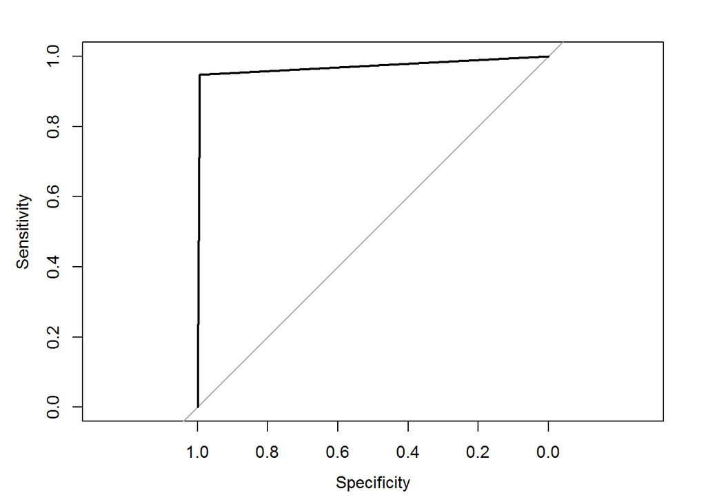

```
##
## Call:
## roc.default(response = labels_out$correct_label, predictor = as.numeric(as.character(maxent_out[,     1])))
##
## Data: as.numeric(as.character(maxent_out[, 1])) in 786 controls (labels_out$correct_label 0) < 169 cases (labels_out$correct_label 1).
## Area under the curve: 0.9702
```

```r
#roc curve
roc_curve<-roc(labels_out$correct_label, as.numeric(as.character(maxent_out[,1])))
plot(roc_curve)
```

### Exploratory

Which words signal spam? While I couldn’t find any documenation to explain `Weight` in the `maxent_model@weights`, it appears that the extreme values (positive or negative) are the most important words. I match the terms from `dtm$dimnames$Terms` to the output of `maxent_model@weights` using the `Feature` column, and then arrange by the `Weight` to get the most important words. I show the top 15 terms by `Weight`.

```r
library(tidyr)
library(dplyr)

#get model weights
maxent_df<-maxent_model@weights
maxent_df$Weight_Adj<-as.numeric(as.character(maxent_df$Weight))
maxent_df$Feature_Adj<-as.numeric(as.character(maxent_df$Feature))

#get terms
maxent_df$Terms<-dtm$dimnames$Terms[maxent_df$Feature_Adj]

#view top terms by weight
head(arrange(maxent_df, desc(Weight_Adj)), n =15)
```

```
##        Weight      Label Feature Weight_Adj Feature_Adj        Terms
## 1        5.86 0             1671       5.86        1671        wrote
## 2        4.96 0             1572       4.96        1572          url
## 3        3.57 0              404       3.57         404         date
## 4        3.52 0             1017       3.52        1017    newsisfre
## 5        2.89 0             1386       2.89        1386 spamassassin
## 6        2.87 1              809       2.87         809     internet
## 7        2.52 1             1062       2.52        1062        order
## 8        2.51 0              951       2.51         951       messag
## 9        2.37 0             1574       2.37        1574          use
## 10       2.32 1             1242       2.32        1242        remov
## 11       2.15 0              657       2.15         657         geeg
## 12       2.14 0             1063       2.14        1063          org
## 13       2.09 1              748       2.09         748        href=
## 14       2.06 1              980       2.06         980        money
## 15       2.02 1                7       2.02           7         <br>
```

If I have interpreted this correctly, on top we see that “wrote”, “url”, and “date” appear to signal `ham` while “internet”, “order”, and “remove” signal `spam`. For spam, “order” could signal money order (as “money” appears lower in the list), and “remov” could be part of “if you wish to be removed from this mailing list…”. So there is some intuitive plausibility to this result.

### Conclusion

I have shown that emails can be classified as `spam` and `ham` using the `tm` and `RTextTools` packages, and that such classification is very effective on the data being used.